# Investigating Differentially Expressed Genes in Latent HIV+ T Cells

#### Create PCA plots - one using sample type and other using donor variables

```r
library("pcaExplorer")
```

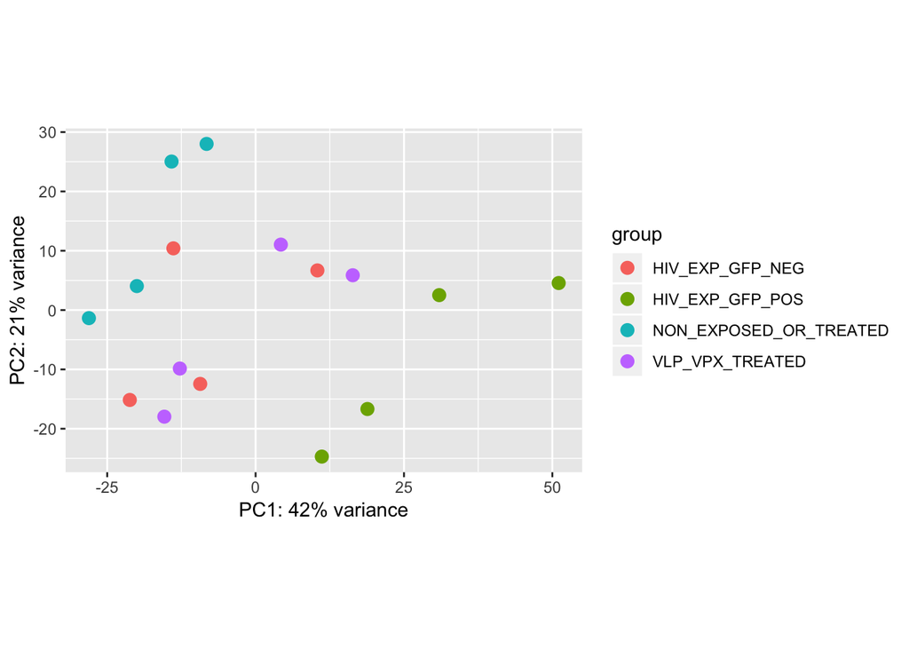

```r
rld <- rlog(dds)

plotPCA(rld, intgroup="sample_type")
```

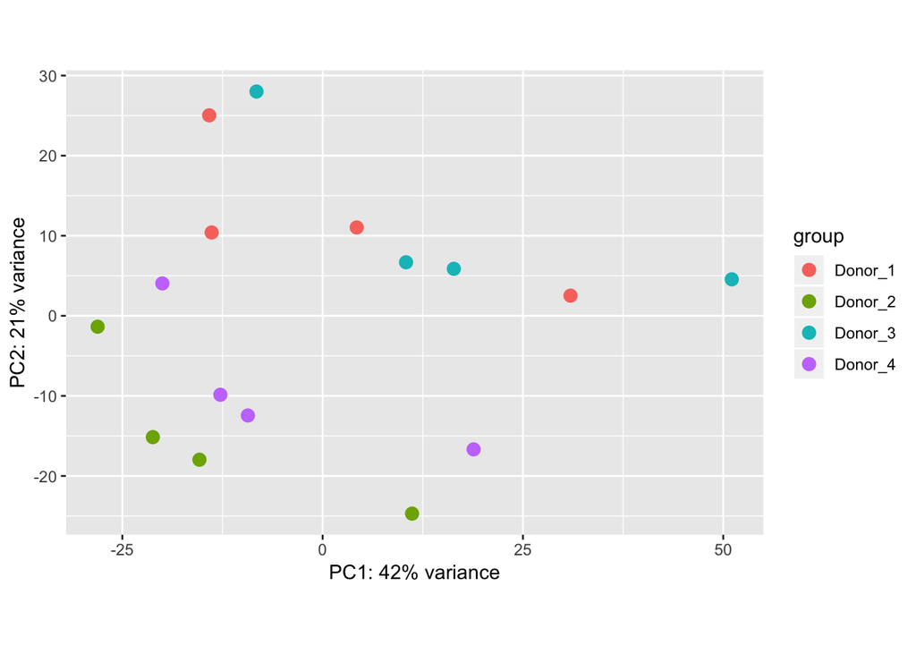

```r
plotPCA(rld, intgroup="donor")
```

#### Create euclidean distance heatmaps of the samples

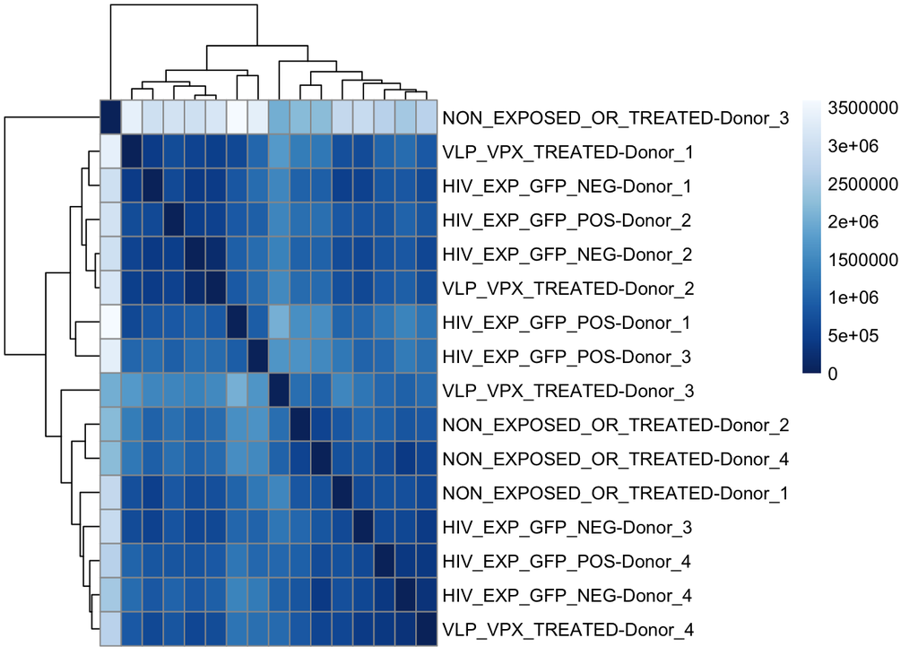

```r
sampleDists <- dist(t(assay(dds)))

library("RColorBrewer")
library("pheatmap")

sampleDistMatrix <- as.matrix(sampleDists)
rownames(sampleDistMatrix) <- paste(dds$sample_type, dds$donor, sep="-")
colnames(sampleDistMatrix) <- NULL
colors <- colorRampPalette( rev(brewer.pal(9, "Blues")) )(255)
pheatmap(sampleDistMatrix,
         clustering_distance_rows=sampleDists,
         clustering_distance_cols=sampleDists,
         col=colors)
```

#### Look at Gene of Interest in Referenced Descours et al. Study, “CD32a”

NOTE: This gene name has synonym names, which in my analysis the gene synonym is “FCGR2A”

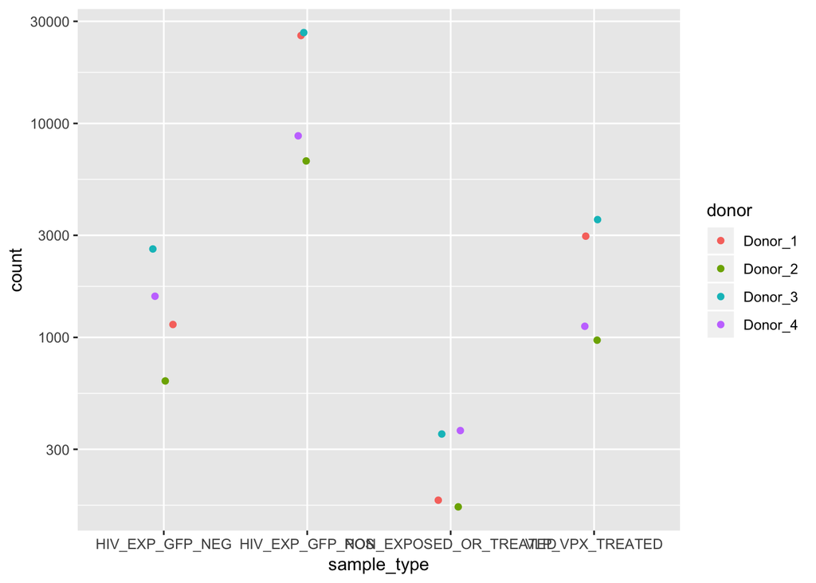

```r
d <- plotCounts(dds, gene=which(row.names(res) == "FCGR2A"), intgroup=c("sample_type"),
                returnData=TRUE)
library("ggplot2")
ggplot(d, aes(x=sample_type, y=count, color=donor)) +
  geom_point(position=position_jitter(w=0.1,h=0)) +
  scale_y_log10()
```

#### Generate Histogram plot of log2 Fold Changes in the Surface Proteins of interest identified in Descours et al., using standard error for error bars

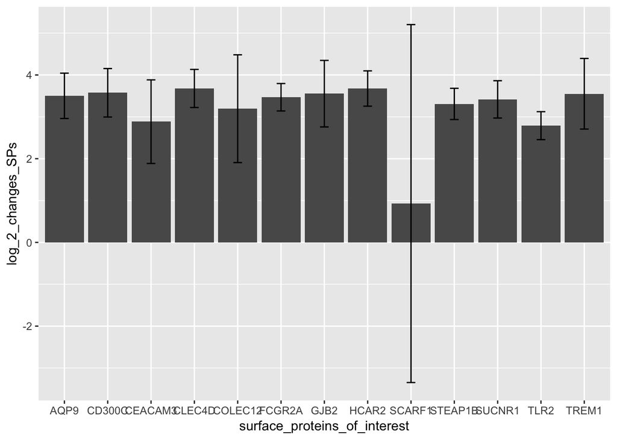

```r
surface_proteins_of_interest <- c("AQP9", "SUCNR1", "CEACAM3", "STEAP1B", "GJB2", "COLEC12", "HCAR2", "TREM1", "SCARF1", "CD300C", "CLEC4D", "TLR2", "FCGR2A")

surface_proteins_of_interest_indexes <- c()
for(i in surface_proteins_of_interest){
  surface_proteins_of_interest_indexes <- c(surface_proteins_of_interest_indexes, which(row.names(res) == i))
}

log_2_changes_SPs <- c()

##standard errors:
se_SPs <- c()

pvals_SPs <- c()

for(i in surface_proteins_of_interest_indexes){
  log_2_changes_SPs <- c(log_2_changes_SPs, res$log2FoldChange[i])
  se_SPs <- c(se_SPs, res$lfcSE[i])
  pvals_SPs <- c(pvals_SPs, res$padj[i])
}

#res$lfcSE

SP_df <- data.frame(surface_proteins_of_interest, log_2_changes_SPs, se_SPs, pvals_SPs)

SP_plot <- ggplot(SP_df, aes(surface_proteins_of_interest, log_2_changes_SPs)) +
                   geom_col() + geom_errorbar(aes(ymin = log_2_changes_SPs - se_SPs, ymax = log_2_changes_SPs + se_SPs), width=0.2)

SP_plot
```

```r
SP_df
```

```
##    surface_proteins_of_interest log_2_changes_SPs    se_SPs    pvals_SPs
## 1                          AQP9          3.501981 0.5414724 4.231014e-09
## 2                        SUCNR1          3.417044 0.4460328 1.328625e-12
## 3                       CEACAM3          2.884603 0.9988799 2.593390e-02
## 4                       STEAP1B          3.308580 0.3727141 8.504730e-17
## 5                          GJB2          3.553320 0.7946132 1.339724e-04
## 6                       COLEC12          3.194292 1.2874033 6.571106e-02
## 7                         HCAR2          3.676449 0.4218694 3.429140e-16
## 8                         TREM1          3.550942 0.8435522 3.841323e-04
## 9                        SCARF1          0.928135 4.2756143           NA
## 10                       CD300C          3.574584 0.5787238 2.412550e-08
## 11                       CLEC4D          3.677840 0.4550930 5.713108e-14
## 12                         TLR2          2.789347 0.3338482 6.508054e-15
## 13                       FCGR2A          3.468207 0.3280769 1.088611e-23
```

```r
## used the following to investigate genes one by one -- had to look up many name synonyms on ensembl
which(row.names(res) == "AQP9")
```

```
## [1] 29003
```

```r
#which(row.names(res) == "CA12")  ### LEFT OUT!!!! to fit all in plot
#which(row.names(res) == "SUCNR1") ##GPR91
#which(row.names(res) == "CEACAM3") ##CD66d
#which(row.names(res) == "STEAP1B")
#which(row.names(res) == "GJB2")
#which(row.names(res) == "COLEC12")
#which(row.names(res) == "HCAR2") #NIACR1
#which(row.names(res) == "TREM1") #CD354
#unable to identify CSF2RA
#which(row.names(res) == "SCARF1")
#which(row.names(res) == "CD300C") #CD300c
#which(row.names(res) == "CLEC4D")
#which(row.names(res) == "TLR2")
#which(row.names(res) == "FCGR2A")
```

## Results

Upon observing the count comparisons for the gene of interest in Descours et al., “CD32a,” one can observe that the expression of CD32a (aka. FCGR2A) is significantly higher in the HIV infected cells.

When looking at the PCA plots, one can notice that there is not noticably significant clustering among the sample types, and rather appears to be a result of both the donor cell line as well as the sample type. This same trend additionally appears true for the heatmapping of the different samples.

## Discussion

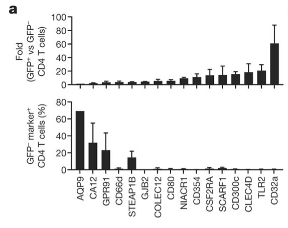

Figure 2a. Expression values, determing by flow cytometry screening of 16 Surface Proteins Found to Be Upregulation in the HIV+ Cells as compared to HIV-negative controls <sup>7</sup>

While this was at first concerning, I later learned that these findings had been refuted a year later by a different research group, which later published the following article in Nature as well:

Osuna, Christa E., et al. “Evidence that CD32a does not mark the HIV-1 latent reservoir.” Nature 561.7723 (2018):E20<sup>8</sup>

In this article, the researchers found no siginficant differences in screening via flow cytometry for the CD32a surface marker protein. However, the researchers in this article did not investigate differential gene expression in the cells.<sup>8</sup>

Finally, a few points of concern are left. Regarding my own analysis, high duplication levels seen in the FastQCs of the raw read counts begs for a method to help cut down on these duplicats. In future analyses, it might be beneficial to use the –ignoreDup option in featureCounts to help elminate the influence of these duplicates on the differential gene expression analysis. Of note as well is that Descours et al. used the STAR aligner and DESeq2 as well, however they performed counting using HT-SeqCount, which could be a counting tool I could experiment with. Additionally, regarding the sample preparation done by Descours et al., the researchers only incubated the HIV infected cells for 4 days. It is unclear, however, as to whether this time period is sufficient for identifying indicative markers of differential gene expression of latently infected HIV+ T cells, as it has been known that HIV can lay dormant in cells for years or longer.

## Key Data Sets

```r
library("knitr")

data_sets <- data.frame(file_name=c("ProjectGenesDataFrame.csv", "counts_table_prepared.csv"), file_description=c("Used to keep track of gene_id -> gene_symbols", "Prepared counts table, ready for input into DESeq2"))

kable(data_sets)
```

| file_name | file_description |
| --- | --- |
| ProjectGenesDataFrame.csv | Used to keep track of gene_id -> gene_symbols |
| counts_table_prepared.csv | Prepared counts table, ready for input into DESeq2 |

## References

1. UNAIDS. Global HIV & AIDS statistics — 2018 fact sheet. (2018). Available at: http://www.unaids.org/en/resources/fact-sheet. (Accessed: 10th March 2019)
2. Gebo, K. A. et al. Contemporary costs of HIV healthcare in the HAART era. AIDS (London, England) 24, 2705–15 (2010).
3. Fonsah, J. Y. et al. Adherence to Antiretroviral Therapy (ART) in Yaoundé- Cameroon: Association with Opportunistic Infections, Depression, ART Regimen and Side Effects. PLOS ONE 12, e0170893 (2017).
4. Siliciano, R. F. & Greene, W. C. HIV latency. Cold Spring Harbor perspectives in medicine 1, a007096 (2011).
5. Cure, T. I. A. S. S. W. G. on H. et al. Towards an HIV cure: a global scientific strategy. Nature Reviews Immunology 12, 607–614 (2012).
6. Darcis, G., Van Driessche, B. & Van Lint, C. HIV Latency: Should We Shock or Lock? Trends in Immunology 38, 217–228 (2017).
7. Descours, B. et al. CD32a is a marker of a CD4 T-cell HIV reservoir harbouring replication-competent proviruses. Nature (2017). doi:10.1038/nature21710
8. Osuna, Christa E., et al. “Evidence that CD32a does not mark the HIV-1 latent reservoir.” Nature 561.7723 (2018):E20